# Honey Production

**Honey Production**

| S.no | Attribute | Description |
| --- | --- | --- |
| 1 | numcol | Number of honey producing colonies. |
| 2 | yield percol | Honey yield per colony. (Unit is pounds) |
| 3 | total prod | Total production (numcol x yieldpercol). (Unit is pounds) |
| 4 | price per lb | Refers to average price per pound based on expanded sales. (Unit is dollars.) |
| 5 | prodvalue | Value of production (total prod x priceperlb). (Unit is dollars.) |
| 6 | Stocks | Refers to stocks held by producers. (Unit is pounds) |
| 7 | Year | Calendar year. |
| 8 | State | Different states' names. |

*1. Import required libraries and read the dataset.*

```python
# Numerical libraries
import numpy as np

# to handle data in form of rows and columns
import pandas as pd

# importing ploting libraries
import matplotlib.pyplot as plt

#importing seaborn for statistical plots
import seaborn as sns
```

```python
honey_df = pd.read_csv("honeyproduction.csv")
honey_df.head()
```

|  | state | numcol | yieldpercol | totalprod | stocks | priceperlb | prodvalue | year |
| --- | --- | --- | --- | --- | --- | --- | --- | --- |
| 0 | AL | 16000.0 | 71 | 1136000.0 | 159000.0 | 0.72 | 818000.0 | 1998 |
| 1 | AZ | 55000.0 | 60 | 3300000.0 | 1485000.0 | 0.64 | 2112000.0 | 1998 |
| 2 | AR | 53000.0 | 65 | 3445000.0 | 1688000.0 | 0.59 | 2033000.0 | 1998 |
| 3 | CA | 450000.0 | 83 | 37350000.0 | 12326000.0 | 0.62 | 23157000.0 | 1998 |
| 4 | CO | 27000.0 | 72 | 1944000.0 | 1594000.0 | 0.70 | 1361000.0 | 1998 |

```python
honey_df.tail()
```

|  | state | numcol | yieldpercol | totalprod | stocks | priceperlb | prodvalue | year |
| --- | --- | --- | --- | --- | --- | --- | --- | --- |
| 621 | VA | 4000.0 | 41 | 164000.0 | 23000.0 | 3.77 | 618000.0 | 2012 |
| 622 | WA | 62000.0 | 41 | 2542000.0 | 1017000.0 | 2.38 | 6050000.0 | 2012 |
| 623 | WV | 6000.0 | 48 | 288000.0 | 95000.0 | 2.91 | 838000.0 | 2012 |
| 624 | WI | 60000.0 | 69 | 4140000.0 | 1863000.0 | 2.05 | 8487000.0 | 2012 |
| 625 | WY | 50000.0 | 51 | 2550000.0 | 459000.0 | 1.87 | 4769000.0 | 2012 |

### Observations :

We can import the necessary pandas library and read the dataset using the *pd.read_csv() function.*

The head() function is then used to *display the first few rows of the dataset*, allowing us to get a glimpse of the data structure and the variables present.

After running the code, we will see the first few rows of the dataset printed in the console. This will provide an overview of the dataset, including the column names and the corresponding values for each row.

*2. Check the first few samples, shape, info of the data and try to familiarize yourself with different features.*

```python
honey_df.shape
```

```
(626, 8)
```

```python
honey_df.info()
```

```
<class 'pandas.core.frame.DataFrame'>
RangeIndex: 626 entries, 0 to 625
Data columns (total 8 columns):
 #   Column       Non-Null Count  Dtype
---  ------       --------------  -----
 0   state        626 non-null    object
 1   numcol       626 non-null    float64
 2   yieldpercol  626 non-null    int64
 3   totalprod    626 non-null    float64
 4   stocks       626 non-null    float64
 5   priceperlb   626 non-null    float64
 6   prodvalue    626 non-null    float64
 7   year         626 non-null    int64
dtypes: float64(5), int64(2), object(1)
memory usage: 39.2+ KB
```

```python
honey_df.describe().apply(lambda s: s.apply('{0:.2f}'.format)).transpose()
```

|  | count | mean | std | min | 25% | 50% | 75% | max |
| --- | --- | --- | --- | --- | --- | --- | --- | --- |
| numcol | 626.00 | 60284.35 | 91077.09 | 2000.00 | 9000.00 | 26000.00 | 63750.00 | 510000.00 |
| yieldpercol | 626.00 | 62.01 | 19.46 | 19.00 | 48.00 | 60.00 | 74.00 | 136.00 |
| totalprod | 626.00 | 4169086.26 | 6883846.75 | 84000.00 | 475000.00 | 1533000.00 | 4175250.00 | 46410000.00 |
| stocks | 626.00 | 1318859.42 | 2272963.67 | 8000.00 | 143000.00 | 439500.00 | 1489500.00 | 13800000.00 |
| priceperlb | 626.00 | 1.41 | 0.64 | 0.49 | 0.93 | 1.36 | 1.68 | 4.15 |
| prodvalue | 626.00 | 4715741.21 | 7976109.77 | 162000.00 | 759250.00 | 1841500.00 | 4703250.00 | 69615000.00 |
| year | 626.00 | 2004.86 | 4.32 | 1998.00 | 2001.00 | 2005.00 | 2009.00 | 2012.00 |

```python
honey_df.isnull().any()
```

```
state          False
numcol         False
yieldpercol    False
totalprod      False
stocks         False
priceperlb     False
prodvalue      False
year           False
dtype: bool
```

### Observations :

*honey_df.shape* shows the dimensions of the dataset, represented as (rows, columns).So there are *626 rows* and *8 columns.*

*honey_df.info()* provides a summary of the dataset, including the column names, the count of non-null values in each column, and the data types of the columns. It helps in understanding the completeness of the data and the data types of each feature.

Based on the displayed information, you can make the following inferences:

The dataset contains multiple columns representing different attributes of honey production.

Each column has a specific data type, such as *integers, floats,* or *objects,* which reflects the nature of the corresponding feature.

We can identify any missing values in the dataset by checking the non-null counts for each column.

These inferences help in understanding the *overall structure* and *characteristics of the dataset*, enabling you to perform further analysis and *data manipulation tasks.*

*3. Display the percentage distribution of the data in each year using the pie chart.*

```python
# Calculate the total production for each year
total_production = honey_df.groupby('year')['totalprod'].sum()
total_production
```

```
year
1998    219519000.0
1999    202387000.0
2000    219558000.0
2001    185748000.0
2002    171265000.0
2003    181372000.0
2004    182729000.0
2005    173969000.0
2006    154238000.0
2007    147621000.0
2008    162972000.0
2009    145068000.0
2010    175294000.0
2011    147201000.0
2012    140907000.0
Name: totalprod, dtype: float64
```

```python
# Calculate the percentage distribution of total production for each year
percent_distribution = total_production / total_production.sum() * 100
percent_distribution
```

```
year
1998    8.411180
1999    7.754743
2000    8.412674
2001    7.117196
2002    6.562260
2003    6.949523
2004    7.001519
2005    6.665867
2006    5.909846
2007    5.656306
2008    6.244502
2009    5.558485
2010    6.716636
2011    5.640214
2012    5.399050
Name: totalprod, dtype: float64
```

```python
percent_distribution.index
```

```
Int64Index([1998, 1999, 2000, 2001, 2002, 2003, 2004, 2005, 2006, 2007, 2008,
            2009, 2010, 2011, 2012],
           dtype='int64', name='year')
```

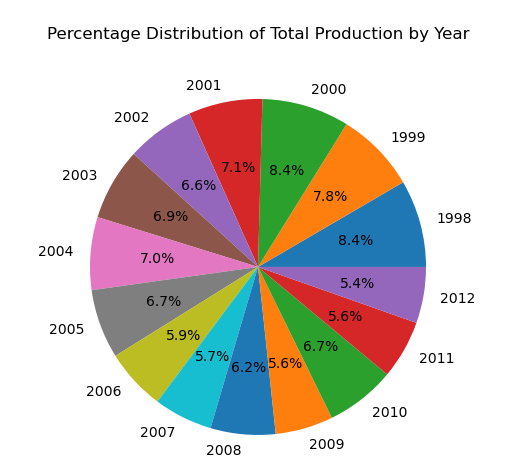

```python
# Create a pie chart
plt.pie(percent_distribution, labels = percent_distribution.index, autopct='%1.1f%%')
plt.title('\nPercentage Distribution of Total Production by Year\n\n')
plt.axis('equal')
plt.show()
```

### Observations :

The pie chart visually represents the *distribution of the data* across different years.

We can observe the relative proportions of data across different years and identify any *imbalances* or *variations.*

The percentage values displayed on the chart indicate the *specific percentage distribution* for each year.

We can use this visualization to understand the distribution pattern, identify years with significant data contributions, or assess the availability of data over time.

*4. Plot and Understand the distribution of the variable "price per lb" using displot, and write your findings.*

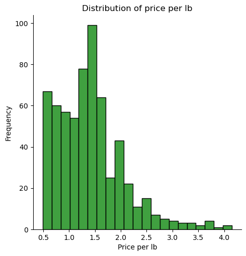

```python
# Create a displot

sns.displot(honey_df['priceperlb'], color= 'green')
plt.title("Distribution of price per lb")
plt.xlabel("Price per lb")
plt.ylabel("Frequency")
plt.show()
```

### Observations :

The distribution of the "price per lb" variable is visualized in the histogram. The x-axis represents different *price values,* and the y-axis represents the *count or frequency of those values.*

The histogram provides insights into the frequency of different price ranges. We can observe peaks or modes that indicate *common price levels or ranges.*

The shape of the distribution can be used to infer characteristics such as *skewness* (e.g., left-skewed or right-skewed), *multimodality* (multiple peaks), or *symmetry.*

The count or frequency values on the y-axis can give an indication of the *relative prevalence of different price levels.*

*5. Plot and understand the relationship between the variables 'numcol' and 'prodval' through scatterplot, and write your findings.*

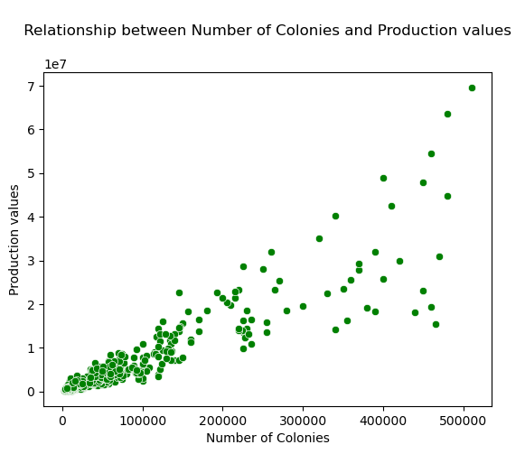

```python
# Create a scatter plot

sns.scatterplot(data = honey_df, x = "numcol", y = "prodvalue" , color = 'green')
plt.title("\n Relationship between Number of Colonies and Production values \n")
plt.xlabel("Number of Colonies")
plt.ylabel("Production values")
plt.show()
```

### Observations :

The scatter plot visualizes the relationship between the *'numcol'* and *'prodval'* variables.

Each data point represents a specific observation, where the x-coordinate represents the *number of colonies* and the y-coordinate represents the *production value.*

You can observe the general pattern or trend of the relationship between the two variables. For example, if the points are clustered in an upward direction, it suggests a *positive relationship,* indicating that as the number of colonies increases, the production value also tends to increase.

The scatter plot can help identify any *outliers* or extreme values that deviate from the overall pattern.

These outliers may indicate unusual or influential observations that require further investigation.

The distribution or concentration of points within the plot can provide insights into the density or prevalence of certain combinations of the 'numcol' and 'prodval' values.

The scatter plot allows you to visually assess the strength and direction of the relationship between the variables. If the points are more *tightly clustered* and form a clear pattern, it suggests a *stronger relationship.*

*6. Plot and understand the relationship between categorical variable 'year' and a numerical variable 'prodvalue' through boxplot, and write your findings.*

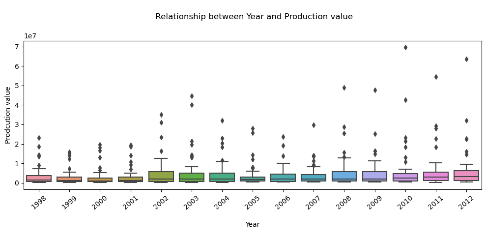

```python
# Create a boxplots

plt.figure(figsize=(10,5))
sns.boxplot(data = honey_df, x = 'year' , y = 'prodvalue' , dodge = True)
plt.title("\n Relationship between Year and Production value\n\n")
plt.xlabel("\nYear\n", loc = 'center')
plt.ylabel("Prodcution value")
plt.xticks(rotation=40)
plt.tight_layout()# To Adjust the spacing to prevent overlapping
plt.show()
```

### Observations :

The boxplot visualizes the distribution of *'prodvalue'* for each *'year'.* Each box represents the *interquartile range (IQR)* of the 'prodvalue' values for a specific 'year'.

The line inside the box represents the *median* 'prodvalue' for each 'year'.

The whiskers extend from the box to show the range of 'prodvalue' values within *1.5 times* the IQR.

The plot also identifies any potential outliers as individual points outside the whiskers.

By comparing the boxes and whiskers across different 'year' categories, you can assess differences in the distribution of 'prodvalue' and identify any trends or patterns.

The boxplot allows you to understand the *central tendency, spread, and distribution* of 'prodvalue' for each 'year', and compare the variability between different years.

You can also identify any unusual or extreme values in the 'prodvalue' variable for specific years, which may require further investigation.

*7. Visualize and understand the relationship between the multiple pairs of variables throughout different years using pairplot and add your inferences. (use columns 'numcol', 'yield percol', 'total prod', 'prodvalue','year')*

```python
honey_df.columns
```

```
Index(['state', 'numcol', 'yieldpercol', 'totalprod', 'stocks', 'priceperlb',
       'prodvalue', 'year'],
      dtype='object')
```

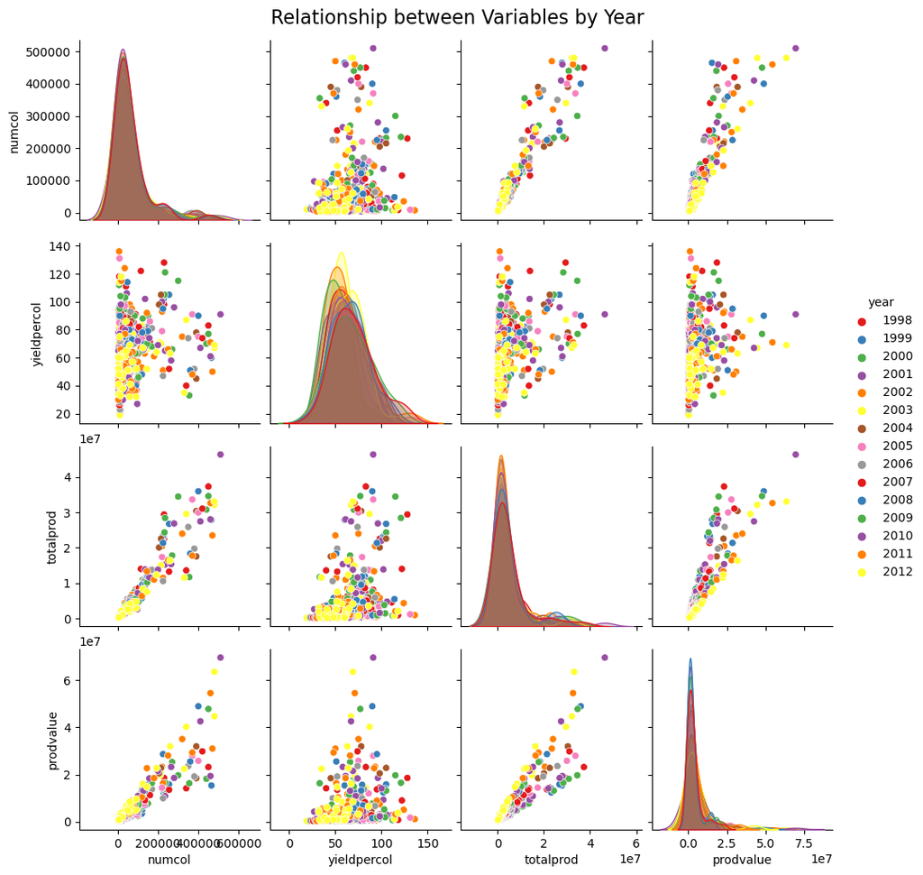

```python
# To Create a pairplot

plt.figure(figsize=(5,5))
columns = ['numcol','yieldpercol','totalprod','prodvalue','year']
pairplot = sns.pairplot(honey_df[columns], hue = 'year' , palette = 'Set1' )
pairplot.fig.suptitle('Relationship between Variables by Year', y=1.02, fontsize=16)
plt.show()
```

### Observations :

**Honey yield per colony (yield percol):**  
There is a wide variation in yield per colony, and it does not show a consistent pattern with other variables.Some years exhibit higher yields per colony compared to others, suggesting potential factors influencing colony productivity.

**Total production (total prod):**  
Total production demonstrates a strong positive correlation with the number of colonies.Years with more colonies tend to have higher total honey production.

**Value of production (prodvalue):**  
The value of production exhibits a positive relationship with the number of colonies and total production.Higher honey production leads to increased production value.

**Year:**  
Each year is represented by a different color in the pairplot, allowing us to compare the relationships between variables across different years. By examining the color-coded data points, we can observe any changes or trends in the relationships between variables over time.It's important to note that these inferences are based on the visual observations from the pairplot.

*8. Display the correlation values using a plot and add your inferences. (use columns 'numcol', 'yield percol', 'total prod', 'stocks', 'price per lb', 'prodvalue')*

```python
honey_df.columns
```

```
Index(['state', 'numcol', 'yieldpercol', 'totalprod', 'stocks', 'priceperlb',
       'prodvalue', 'year'],
      dtype='object')
```

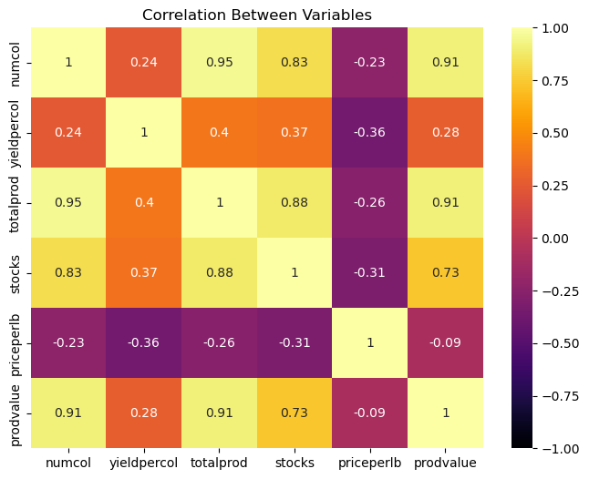

```python
# To create a correlation matrix

columns = ['numcol', 'yieldpercol', 'totalprod', 'stocks', 'priceperlb', 'prodvalue']
correlation_matrix = honey_df[columns].corr()

plt.figure(figsize=(8, 6))
sns.heatmap(correlation_matrix, annot=True, cmap='inferno', vmin=-1, vmax=1)
plt.title('Correlation Between Variables')
plt.show()
```

### Observations :

The heatmap plot visualizes the correlation between the selected columns using *color-coded cells.* Each cell represents the correlation coefficient between two variables.

You can observe the patterns and relationships between the variables based on the *color distribution* in the heatmap.

Correlation values close to 1 or -1 indicate a *strong positive or negative linear* relationship, respectively. Values close to 0 indicate a *weak or no linear relationship.*

The diagonal line of the heatmap represents the correlation of each variable with itself, which is always *1 (or 100%).*

You can use the correlation values to identify which variables are *strongly correlated or inversely correlated* with each other.

The correlation matrix provides insights into the interdependencies between the selected variables, helping *identify potential associations* and *guiding further analysis.*

Thank you

By  
Anies Ghousia.J